# Risk Factor Analysis

## Outcome Variable

**Outcome Variable:** sstunted

## Predictor Variables

**Intervention Variable:** hdlvry

**Adjustment Set:**

- arm
- sex
- W_mage
- meducyrs
- feducyrs
- hhwealth_quart
- single
- W_nrooms
- brthmon
- W_parity
- impsan
- delta_W_mage
- delta_meducyrs
- delta_feducyrs
- delta_hhwealth_quart
- delta_single
- delta_W_nrooms
- delta_brthmon
- delta_W_parity
- delta_impsan

## Stratifying Variables

The analysis was stratified on these variable(s):

- agecat
- studyid
- country

## Data Summary

| agecat | studyid | country | hdlvry | sstunted | n_cell | n |
| --- | --- | --- | --- | --- | --- | --- |
| Birth | CMC-V-BCS-2002 | INDIA | 0 | 0 | 88 | 92 |
| Birth | CMC-V-BCS-2002 | INDIA | 0 | 1 | 4 | 92 |
| Birth | CMC-V-BCS-2002 | INDIA | 1 | 0 | 0 | 92 |
| Birth | CMC-V-BCS-2002 | INDIA | 1 | 1 | 0 | 92 |
| Birth | COHORTS | INDIA | 0 | 0 | 2855 | 4694 |
| Birth | COHORTS | INDIA | 0 | 1 | 83 | 4694 |
| Birth | COHORTS | INDIA | 1 | 0 | 1702 | 4694 |
| Birth | COHORTS | INDIA | 1 | 1 | 54 | 4694 |
| Birth | EE | PAKISTAN | 0 | 0 | 130 | 238 |
| Birth | EE | PAKISTAN | 0 | 1 | 31 | 238 |
| Birth | EE | PAKISTAN | 1 | 0 | 60 | 238 |
| Birth | EE | PAKISTAN | 1 | 1 | 17 | 238 |
| Birth | GMS-Nepal | NEPAL | 0 | 0 | 150 | 646 |
| Birth | GMS-Nepal | NEPAL | 0 | 1 | 7 | 646 |
| Birth | GMS-Nepal | NEPAL | 1 | 0 | 469 | 646 |
| Birth | GMS-Nepal | NEPAL | 1 | 1 | 20 | 646 |
| Birth | IRC | INDIA | 0 | 0 | 365 | 388 |
| Birth | IRC | INDIA | 0 | 1 | 16 | 388 |
| Birth | IRC | INDIA | 1 | 0 | 7 | 388 |
| Birth | IRC | INDIA | 1 | 1 | 0 | 388 |
| Birth | JiVitA-3 | BANGLADESH | 0 | 0 | 30 | 334 |
| Birth | JiVitA-3 | BANGLADESH | 0 | 1 | 0 | 334 |
| Birth | JiVitA-3 | BANGLADESH | 1 | 0 | 284 | 334 |
| Birth | JiVitA-3 | BANGLADESH | 1 | 1 | 20 | 334 |
| Birth | JiVitA-4 | BANGLADESH | 0 | 0 | 520 | 2808 |
| Birth | JiVitA-4 | BANGLADESH | 0 | 1 | 34 | 2808 |
| Birth | JiVitA-4 | BANGLADESH | 1 | 0 | 2056 | 2808 |
| Birth | JiVitA-4 | BANGLADESH | 1 | 1 | 198 | 2808 |
| Birth | NIH-Crypto | BANGLADESH | 0 | 0 | 558 | 732 |
| Birth | NIH-Crypto | BANGLADESH | 0 | 1 | 9 | 732 |

[output cut: 98 more lines]

The following strata were considered:

- agecat: 24 months, studyid: CMC-V-BCS-2002, country: INDIA
- agecat: 24 months, studyid: COHORTS, country: INDIA
- agecat: 24 months, studyid: EE, country: PAKISTAN
- agecat: 24 months, studyid: GMS-Nepal, country: NEPAL
- agecat: 24 months, studyid: IRC, country: INDIA
- agecat: 24 months, studyid: JiVitA-3, country: BANGLADESH
- agecat: 24 months, studyid: JiVitA-4, country: BANGLADESH
- agecat: 24 months, studyid: NIH-Crypto, country: BANGLADESH
- agecat: 24 months, studyid: PROVIDE, country: BANGLADESH
- agecat: 24 months, studyid: TanzaniaChild2, country: TANZANIA, UNITED REPUBLIC OF
- agecat: 6 months, studyid: CMC-V-BCS-2002, country: INDIA
- agecat: 6 months, studyid: COHORTS, country: INDIA
- agecat: 6 months, studyid: EE, country: PAKISTAN
- agecat: 6 months, studyid: GMS-Nepal, country: NEPAL
- agecat: 6 months, studyid: IRC, country: INDIA
- agecat: 6 months, studyid: JiVitA-3, country: BANGLADESH
- agecat: 6 months, studyid: JiVitA-4, country: BANGLADESH
- agecat: 6 months, studyid: NIH-Crypto, country: BANGLADESH
- agecat: 6 months, studyid: PROVIDE, country: BANGLADESH
- agecat: 6 months, studyid: SAS-CompFeed, country: INDIA
- agecat: 6 months, studyid: SAS-FoodSuppl, country: INDIA
- agecat: 6 months, studyid: TanzaniaChild2, country: TANZANIA, UNITED REPUBLIC OF
- agecat: Birth, studyid: CMC-V-BCS-2002, country: INDIA
- agecat: Birth, studyid: COHORTS, country: INDIA
- agecat: Birth, studyid: EE, country: PAKISTAN
- agecat: Birth, studyid: GMS-Nepal, country: NEPAL
- agecat: Birth, studyid: IRC, country: INDIA
- agecat: Birth, studyid: JiVitA-3, country: BANGLADESH
- agecat: Birth, studyid: JiVitA-4, country: BANGLADESH
- agecat: Birth, studyid: NIH-Crypto, country: BANGLADESH
- agecat: Birth, studyid: PROVIDE, country: BANGLADESH
- agecat: Birth, studyid: SAS-CompFeed, country: INDIA

### Dropped Strata

Some strata were dropped due to rare outcomes:

- agecat: Birth, studyid: CMC-V-BCS-2002, country: INDIA
- agecat: Birth, studyid: IRC, country: INDIA
- agecat: Birth, studyid: JiVitA-3, country: BANGLADESH
- agecat: Birth, studyid: NIH-Crypto, country: BANGLADESH
- agecat: Birth, studyid: PROVIDE, country: BANGLADESH
- agecat: 6 months, studyid: CMC-V-BCS-2002, country: INDIA
- agecat: 6 months, studyid: GMS-Nepal, country: NEPAL
- agecat: 6 months, studyid: IRC, country: INDIA
- agecat: 6 months, studyid: JiVitA-3, country: BANGLADESH
- agecat: 6 months, studyid: NIH-Crypto, country: BANGLADESH
- agecat: 6 months, studyid: TanzaniaChild2, country: TANZANIA, UNITED REPUBLIC OF
- agecat: 24 months, studyid: CMC-V-BCS-2002, country: INDIA
- agecat: 24 months, studyid: IRC, country: INDIA
- agecat: 24 months, studyid: JiVitA-3, country: BANGLADESH
- agecat: 24 months, studyid: TanzaniaChild2, country: TANZANIA, UNITED REPUBLIC OF

## Methods Detail

We’re interested in the causal parameters $E[Y_a]$ for all values of $a \in \mathcal{A}$. These parameters represent the mean outcome if, possibly contrary to fact, we intervened to set all units to have $A=a$. Under the randomization and positivity assumptions, these are identified by the statistical parameters $\psi_a=E_W[E_{Y|A,W}(Y|A=a,W)]$. In addition, we’re interested in the mean of $Y$, $E[Y]$ under no intervention (the observed mean). We will estimate these parameters by using SuperLearner to fit the relevant likelihood factors – $E_{Y|A,W}(Y|A=a,W)$ and $p(A=a|W)$, and then updating our likelihood fit using a joint TMLE.

For unadjusted analyses ($W=\{\}$), initial likelihoods were estimated using Lrnr_glm to estimate the simple $E(Y|A)$ and Lrnr_mean to estimate $p(A)$. For adjusted analyses, a small library containing Lrnr_glmnet, Lrnr_xgboost, and Lrnr_mean was used.

Having estimated these parameters, we will then use the delta method to estimate relative risks and attributable risks relative to a prespecified baseline level of $A$.

# Results Detail

## Results Plots

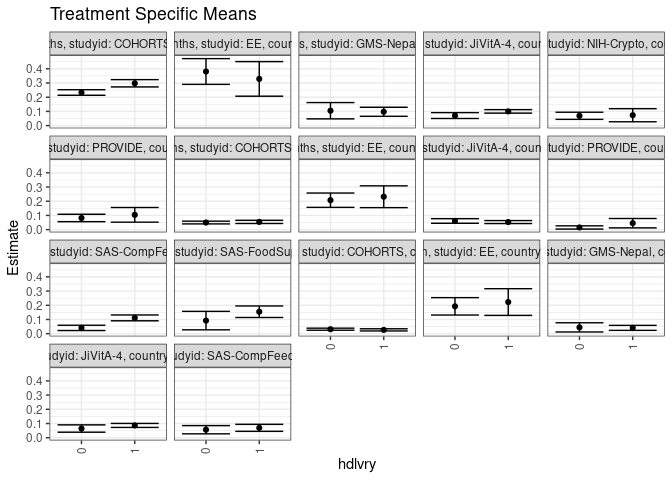

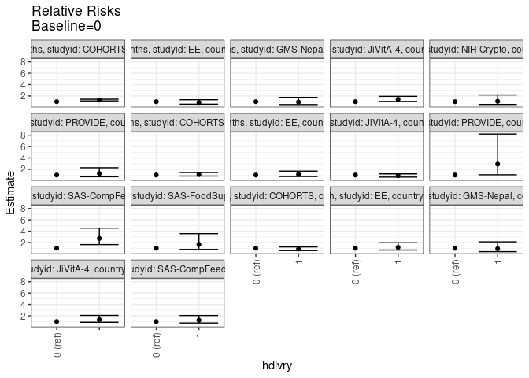

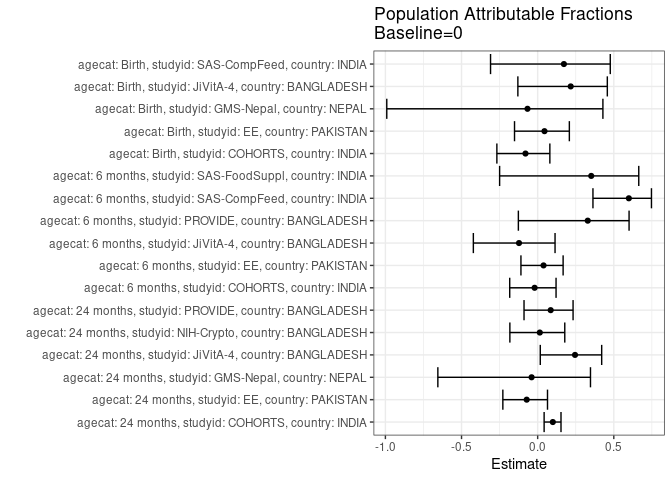

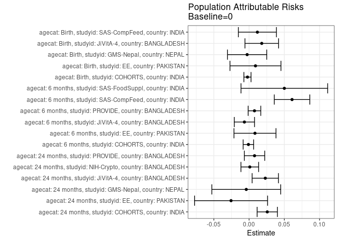

## Results Table

### Parameter: TSM

| agecat | studyid | country | intervention_level | baseline_level | estimate | ci_lower | ci_upper |
| --- | --- | --- | --- | --- | --- | --- | --- |
| Birth | COHORTS | INDIA | 0 | NA | 0.0315212 | 0.0242327 | 0.0388097 |
| Birth | COHORTS | INDIA | 1 | NA | 0.0267431 | 0.0190787 | 0.0344076 |
| Birth | EE | PAKISTAN | 0 | NA | 0.1926337 | 0.1314733 | 0.2537940 |
| Birth | EE | PAKISTAN | 1 | NA | 0.2226902 | 0.1286909 | 0.3166895 |
| Birth | GMS-Nepal | NEPAL | 0 | NA | 0.0445860 | 0.0122765 | 0.0768954 |
| Birth | GMS-Nepal | NEPAL | 1 | NA | 0.0408998 | 0.0233318 | 0.0584678 |
| Birth | JiVitA-4 | BANGLADESH | 0 | NA | 0.0646932 | 0.0388907 | 0.0904958 |
| Birth | JiVitA-4 | BANGLADESH | 1 | NA | 0.0866350 | 0.0725747 | 0.1006953 |
| Birth | SAS-CompFeed | INDIA | 0 | NA | 0.0564516 | 0.0274585 | 0.0854447 |
| Birth | SAS-CompFeed | INDIA | 1 | NA | 0.0697190 | 0.0451096 | 0.0943285 |
| 6 months | COHORTS | INDIA | 0 | NA | 0.0501484 | 0.0404094 | 0.0598874 |
| 6 months | COHORTS | INDIA | 1 | NA | 0.0544874 | 0.0434148 | 0.0655600 |
| 6 months | EE | PAKISTAN | 0 | NA | 0.2073146 | 0.1567648 | 0.2578644 |
| 6 months | EE | PAKISTAN | 1 | NA | 0.2317895 | 0.1549856 | 0.3085934 |
| 6 months | JiVitA-4 | BANGLADESH | 0 | NA | 0.0611576 | 0.0449229 | 0.0773923 |
| 6 months | JiVitA-4 | BANGLADESH | 1 | NA | 0.0534393 | 0.0429769 | 0.0639017 |
| 6 months | PROVIDE | BANGLADESH | 0 | NA | 0.0155556 | 0.0041126 | 0.0269986 |
| 6 months | PROVIDE | BANGLADESH | 1 | NA | 0.0454545 | 0.0125289 | 0.0783802 |
| 6 months | SAS-CompFeed | INDIA | 0 | NA | 0.0408163 | 0.0221750 | 0.0594577 |
| 6 months | SAS-CompFeed | INDIA | 1 | NA | 0.1112288 | 0.0906768 | 0.1317809 |
| 6 months | SAS-FoodSuppl | INDIA | 0 | NA | 0.0921053 | 0.0270064 | 0.1572041 |
| 6 months | SAS-FoodSuppl | INDIA | 1 | NA | 0.1546053 | 0.1139117 | 0.1952988 |
| 24 months | COHORTS | INDIA | 0 | NA | 0.2332196 | 0.2135645 | 0.2528748 |
| 24 months | COHORTS | INDIA | 1 | NA | 0.2980029 | 0.2723195 | 0.3236864 |
| 24 months | EE | PAKISTAN | 0 | NA | 0.3810330 | 0.2904521 | 0.4716139 |
| 24 months | EE | PAKISTAN | 1 | NA | 0.3288322 | 0.2070285 | 0.4506359 |
| 24 months | GMS-Nepal | NEPAL | 0 | NA | 0.1048984 | 0.0474992 | 0.1622976 |
| 24 months | GMS-Nepal | NEPAL | 1 | NA | 0.0973723 | 0.0656238 | 0.1291208 |
| 24 months | JiVitA-4 | BANGLADESH | 0 | NA | 0.0706679 | 0.0499086 | 0.0914271 |
| 24 months | JiVitA-4 | BANGLADESH | 1 | NA | 0.1000811 | 0.0878273 | 0.1123348 |
| 24 months | NIH-Crypto | BANGLADESH | 0 | NA | 0.0690537 | 0.0438979 | 0.0942095 |
| 24 months | NIH-Crypto | BANGLADESH | 1 | NA | 0.0731707 | 0.0271040 | 0.1192374 |
| 24 months | PROVIDE | BANGLADESH | 0 | NA | 0.0822702 | 0.0562252 | 0.1083152 |
| 24 months | PROVIDE | BANGLADESH | 1 | NA | 0.1043892 | 0.0527971 | 0.1559812 |

### Parameter: E(Y)

| agecat | studyid | country | intervention_level | baseline_level | estimate | ci_lower | ci_upper |
| --- | --- | --- | --- | --- | --- | --- | --- |
| Birth | COHORTS | INDIA | NA | NA | 0.0291862 | 0.0243703 | 0.0340021 |
| Birth | EE | PAKISTAN | NA | NA | 0.2016807 | 0.1505956 | 0.2527658 |
| Birth | GMS-Nepal | NEPAL | NA | NA | 0.0417957 | 0.0263516 | 0.0572398 |
| Birth | JiVitA-4 | BANGLADESH | NA | NA | 0.0826211 | 0.0705468 | 0.0946953 |
| Birth | SAS-CompFeed | INDIA | NA | NA | 0.0682028 | 0.0450759 | 0.0913296 |
| 6 months | COHORTS | INDIA | NA | NA | 0.0491594 | 0.0429771 | 0.0553417 |
| 6 months | EE | PAKISTAN | NA | NA | 0.2156334 | 0.1737285 | 0.2575383 |
| 6 months | JiVitA-4 | BANGLADESH | NA | NA | 0.0544824 | 0.0460698 | 0.0628950 |
| 6 months | PROVIDE | BANGLADESH | NA | NA | 0.0231788 | 0.0111688 | 0.0351888 |
| 6 months | SAS-CompFeed | INDIA | NA | NA | 0.1017415 | 0.0806841 | 0.1227990 |
| 6 months | SAS-FoodSuppl | INDIA | NA | NA | 0.1421053 | 0.1069532 | 0.1772573 |
| 24 months | COHORTS | INDIA | NA | NA | 0.2589989 | 0.2445981 | 0.2733997 |
| 24 months | EE | PAKISTAN | NA | NA | 0.3554217 | 0.2823892 | 0.4284541 |
| 24 months | GMS-Nepal | NEPAL | NA | NA | 0.1008772 | 0.0732047 | 0.1285497 |
| 24 months | JiVitA-4 | BANGLADESH | NA | NA | 0.0936330 | 0.0833093 | 0.1039566 |
| 24 months | NIH-Crypto | BANGLADESH | NA | NA | 0.0700389 | 0.0479542 | 0.0921236 |
| 24 months | PROVIDE | BANGLADESH | NA | NA | 0.0899654 | 0.0666186 | 0.1133122 |

### Parameter: RR

| agecat | studyid | country | intervention_level | baseline_level | estimate | ci_lower | ci_upper |
| --- | --- | --- | --- | --- | --- | --- | --- |
| Birth | COHORTS | INDIA | 0 | 0 | 1.0000000 | 1.0000000 | 1.000000 |
| Birth | COHORTS | INDIA | 1 | 0 | 0.8484183 | 0.5871659 | 1.225912 |
| Birth | EE | PAKISTAN | 0 | 0 | 1.0000000 | 1.0000000 | 1.000000 |
| Birth | EE | PAKISTAN | 1 | 0 | 1.1560296 | 0.6813182 | 1.961498 |
| Birth | GMS-Nepal | NEPAL | 0 | 0 | 1.0000000 | 1.0000000 | 1.000000 |
| Birth | GMS-Nepal | NEPAL | 1 | 0 | 0.9173240 | 0.3950715 | 2.129952 |
| Birth | JiVitA-4 | BANGLADESH | 0 | 0 | 1.0000000 | 1.0000000 | 1.000000 |
| Birth | JiVitA-4 | BANGLADESH | 1 | 0 | 1.3391665 | 0.8643402 | 2.074839 |
| Birth | SAS-CompFeed | INDIA | 0 | 0 | 1.0000000 | 1.0000000 | 1.000000 |
| Birth | SAS-CompFeed | INDIA | 1 | 0 | 1.2350230 | 0.7402466 | 2.060505 |
| 6 months | COHORTS | INDIA | 0 | 0 | 1.0000000 | 1.0000000 | 1.000000 |
| 6 months | COHORTS | INDIA | 1 | 0 | 1.0865228 | 0.8211392 | 1.437676 |
| 6 months | EE | PAKISTAN | 0 | 0 | 1.0000000 | 1.0000000 | 1.000000 |
| 6 months | EE | PAKISTAN | 1 | 0 | 1.1180569 | 0.7406482 | 1.687780 |
| 6 months | JiVitA-4 | BANGLADESH | 0 | 0 | 1.0000000 | 1.0000000 | 1.000000 |
| 6 months | JiVitA-4 | BANGLADESH | 1 | 0 | 0.8737968 | 0.6350591 | 1.202283 |
| 6 months | PROVIDE | BANGLADESH | 0 | 0 | 1.0000000 | 1.0000000 | 1.000000 |
| 6 months | PROVIDE | BANGLADESH | 1 | 0 | 2.9220779 | 1.0407048 | 8.204574 |
| 6 months | SAS-CompFeed | INDIA | 0 | 0 | 1.0000000 | 1.0000000 | 1.000000 |
| 6 months | SAS-CompFeed | INDIA | 1 | 0 | 2.7251059 | 1.6370779 | 4.536255 |
| 6 months | SAS-FoodSuppl | INDIA | 0 | 0 | 1.0000000 | 1.0000000 | 1.000000 |
| 6 months | SAS-FoodSuppl | INDIA | 1 | 0 | 1.6785714 | 0.7895724 | 3.568516 |
| 24 months | COHORTS | INDIA | 0 | 0 | 1.0000000 | 1.0000000 | 1.000000 |
| 24 months | COHORTS | INDIA | 1 | 0 | 1.2777781 | 1.1355184 | 1.437860 |
| 24 months | EE | PAKISTAN | 0 | 0 | 1.0000000 | 1.0000000 | 1.000000 |
| 24 months | EE | PAKISTAN | 1 | 0 | 0.8630019 | 0.5549302 | 1.342101 |
| 24 months | GMS-Nepal | NEPAL | 0 | 0 | 1.0000000 | 1.0000000 | 1.000000 |
| 24 months | GMS-Nepal | NEPAL | 1 | 0 | 0.9282536 | 0.4914192 | 1.753401 |
| 24 months | JiVitA-4 | BANGLADESH | 0 | 0 | 1.0000000 | 1.0000000 | 1.000000 |
| 24 months | JiVitA-4 | BANGLADESH | 1 | 0 | 1.4162175 | 1.0348023 | 1.938217 |
| 24 months | NIH-Crypto | BANGLADESH | 0 | 0 | 1.0000000 | 1.0000000 | 1.000000 |
| 24 months | NIH-Crypto | BANGLADESH | 1 | 0 | 1.0596206 | 0.5119815 | 2.193040 |
| 24 months | PROVIDE | BANGLADESH | 0 | 0 | 1.0000000 | 1.0000000 | 1.000000 |
| 24 months | PROVIDE | BANGLADESH | 1 | 0 | 1.2688580 | 0.7053060 | 2.282698 |

### Parameter: PAR

| agecat | studyid | country | intervention_level | baseline_level | estimate | ci_lower | ci_upper |
| --- | --- | --- | --- | --- | --- | --- | --- |
| Birth | COHORTS | INDIA | 0 | NA | -0.0023350 | -0.0074096 | 0.0027396 |
| Birth | EE | PAKISTAN | 0 | NA | 0.0090470 | -0.0270886 | 0.0451827 |
| Birth | GMS-Nepal | NEPAL | 0 | NA | -0.0027903 | -0.0306294 | 0.0250488 |
| Birth | JiVitA-4 | BANGLADESH | 0 | NA | 0.0179278 | -0.0058727 | 0.0417284 |
| Birth | SAS-CompFeed | INDIA | 0 | NA | 0.0117512 | -0.0152182 | 0.0387205 |
| 6 months | COHORTS | INDIA | 0 | NA | -0.0009890 | -0.0084424 | 0.0064643 |
| 6 months | EE | PAKISTAN | 0 | NA | 0.0083188 | -0.0214572 | 0.0380948 |
| 6 months | JiVitA-4 | BANGLADESH | 0 | NA | -0.0066752 | -0.0210587 | 0.0077083 |
| 6 months | PROVIDE | BANGLADESH | 0 | NA | 0.0076233 | -0.0013249 | 0.0165714 |
| 6 months | SAS-CompFeed | INDIA | 0 | NA | 0.0609252 | 0.0357423 | 0.0861081 |
| 6 months | SAS-FoodSuppl | INDIA | 0 | NA | 0.0500000 | -0.0114686 | 0.1114686 |
| 24 months | COHORTS | INDIA | 0 | NA | 0.0257792 | 0.0114135 | 0.0401449 |
| 24 months | EE | PAKISTAN | 0 | NA | -0.0256113 | -0.0774225 | 0.0261999 |
| 24 months | GMS-Nepal | NEPAL | 0 | NA | -0.0040212 | -0.0528474 | 0.0448050 |
| 24 months | JiVitA-4 | BANGLADESH | 0 | NA | 0.0229651 | 0.0043225 | 0.0416077 |
| 24 months | NIH-Crypto | BANGLADESH | 0 | NA | 0.0009852 | -0.0115760 | 0.0135464 |
| 24 months | PROVIDE | BANGLADESH | 0 | NA | 0.0076952 | -0.0068084 | 0.0221988 |

### Parameter: PAF

| agecat | studyid | country | intervention_level | baseline_level | estimate | ci_lower | ci_upper |
| --- | --- | --- | --- | --- | --- | --- | --- |
| Birth | COHORTS | INDIA | 0 | NA | -0.0800031 | -0.2679146 | 0.0800589 |
| Birth | EE | PAKISTAN | 0 | NA | 0.0448581 | -0.1520070 | 0.2080812 |
| Birth | GMS-Nepal | NEPAL | 0 | NA | -0.0667610 | -0.9909847 | 0.4284340 |
| Birth | JiVitA-4 | BANGLADESH | 0 | NA | 0.2169887 | -0.1300286 | 0.4574415 |
| Birth | SAS-CompFeed | INDIA | 0 | NA | 0.1722973 | -0.3094683 | 0.4768169 |
| 6 months | COHORTS | INDIA | 0 | NA | -0.0201191 | -0.1835722 | 0.1207609 |
| 6 months | EE | PAKISTAN | 0 | NA | 0.0385785 | -0.1098486 | 0.1671555 |
| 6 months | JiVitA-4 | BANGLADESH | 0 | NA | -0.1225199 | -0.4223974 | 0.1141358 |
| 6 months | PROVIDE | BANGLADESH | 0 | NA | 0.3288889 | -0.1267356 | 0.6002699 |
| 6 months | SAS-CompFeed | INDIA | 0 | NA | 0.5988233 | 0.3630717 | 0.7473142 |
| 6 months | SAS-FoodSuppl | INDIA | 0 | NA | 0.3518519 | -0.2498734 | 0.6638891 |
| 24 months | COHORTS | INDIA | 0 | NA | 0.0995342 | 0.0424206 | 0.1532412 |
| 24 months | EE | PAKISTAN | 0 | NA | -0.0720590 | -0.2286509 | 0.0645753 |
| 24 months | GMS-Nepal | NEPAL | 0 | NA | -0.0398624 | -0.6555032 | 0.3468368 |
| 24 months | JiVitA-4 | BANGLADESH | 0 | NA | 0.2452673 | 0.0171615 | 0.4204323 |
| 24 months | NIH-Crypto | BANGLADESH | 0 | NA | 0.0140665 | -0.1825711 | 0.1780073 |
| 24 months | PROVIDE | BANGLADESH | 0 | NA | 0.0855354 | -0.0895671 | 0.2324976 |